# Regression

### Part One

I am checking to see if there is a correlation between the number of servings of dairy (this is denoted in the data as milk, so I am making an assumption), and calories from solid fat.

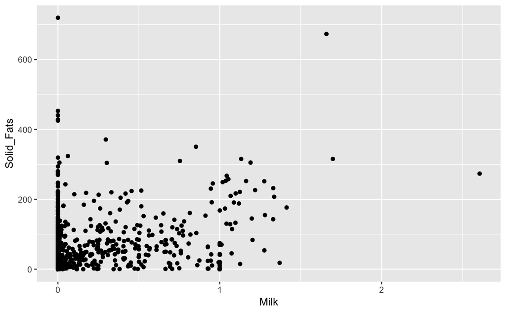

```r
ggplot(nutrition, aes(x=Milk, y=Solid_Fats)) + geom_point()
```

```r
cor(nutrition$Milk, nutrition$Solid_Fats)
```

```
[1] 0.406807
```

There seems to be a modest positive correlation between servings of dairy and calories from solid fat. Now, I will build a linear regression model. The independent variable is servings of dairy, and the dependent variable are calories from fat. In another words, the amount of calories from fat is somehow affected by the number of servings of dairy.

```r
m1 <- lm(data=nutrition, Solid_Fats ~ Milk)
summary(m1)
```

```
Call:
lm(formula = Solid_Fats ~ Milk, data = nutrition)

Residuals:
    Min      1Q  Median      3Q     Max
-141.71  -23.95  -21.58    6.05  695.65

Coefficients:
            Estimate Std. Error t value Pr(>|t|)
(Intercept)   23.953      1.285   18.64   <2e-16 ***
Milk          99.215      4.967   19.98   <2e-16 ***
---
Signif. codes:  0 ‘***’ 0.001 ‘**’ 0.01 ‘*’ 0.05 ‘.’ 0.1 ‘ ’ 1

Residual standard error: 54.55 on 2012 degrees of freedom
Multiple R-squared:  0.1655,    Adjusted R-squared:  0.1651
F-statistic:   399 on 1 and 2012 DF,  p-value: < 2.2e-16
```

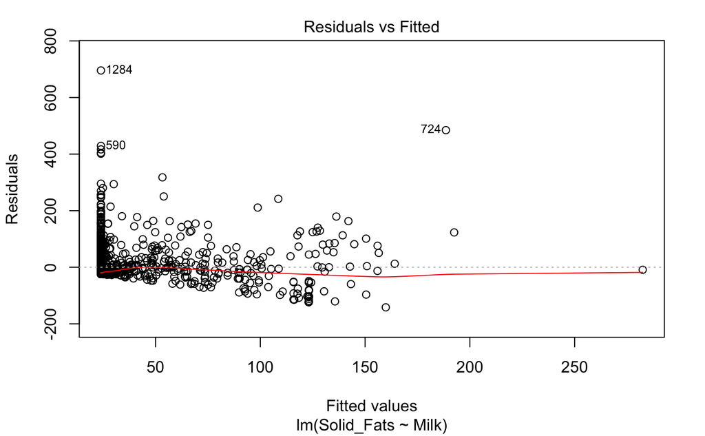

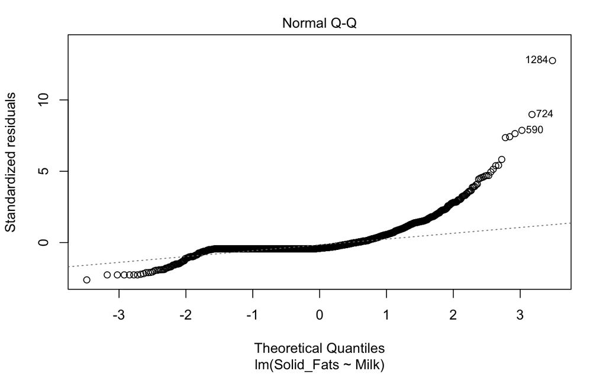

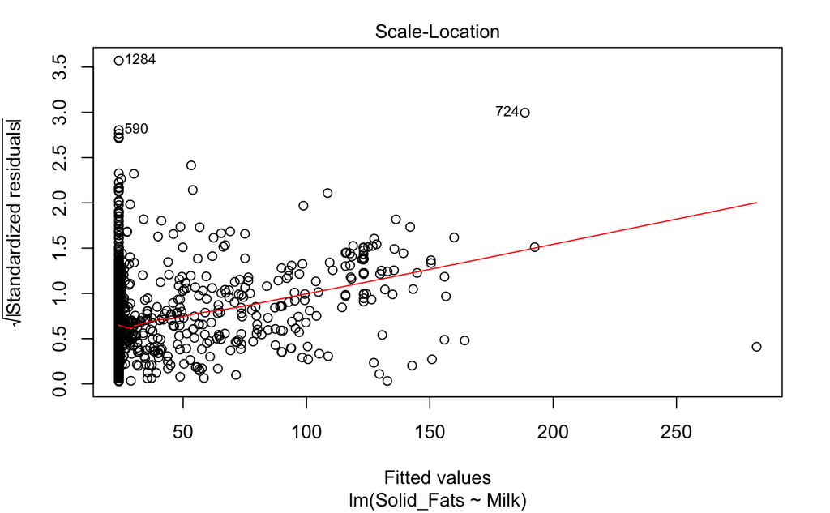

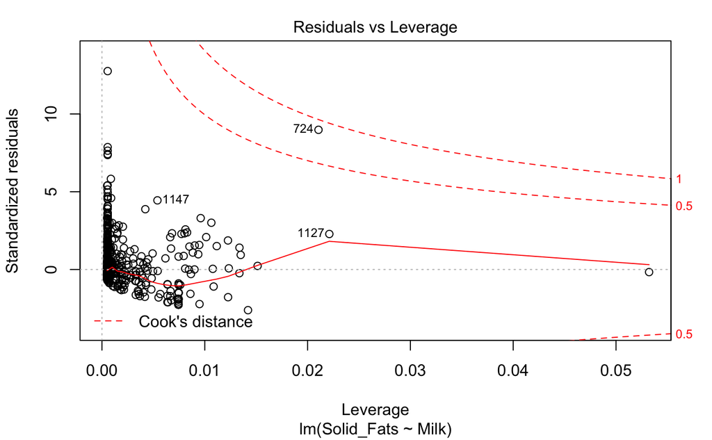

```r
plot(m1)
```